# POMA Normalization Methods

Pol Castellano-Escuder

Duke University

polcaes@gmail.com

1 November 2022

# Contents

**Compiled date**: 2022-11-01

**Last edited**: 2022-08-01

**License**: GPL-3

# 1 Installation

Run the following code to install the Bioconductor version of package.

```r
# install.packages("BiocManager")
BiocManager::install("POMA")
```

# 2 Load Packages

```r
library(POMA)
library(patchwork)
```

# 3 Load Data and Imputation

Let’s create a cleaned `SummarizedExperiment` object from the sample `st000336` data to explore the normalization effects.

```r
# imputation using the default method KNN
example_data <- st000336 %>%
  PomaImpute()
method argument is empty! KNN will be used

example_data
class: SummarizedExperiment
dim: 30 57
metadata(0):
assays(1): ''
rownames(30): x1_methylhistidine x3_methylhistidine ... pyruvate
  succinate
rowData names(0):
colnames(57): DMD004.1.U02 DMD005.1.U02 ... DMD167.5.U02 DMD173.1.U02
colData names(2): group steroids
```

# 4 Normalization

Here we will evaluate ALL normalization methods that POMA offers on the same `SummarizedExperiment` object to compare them (Berg et al. 2006).

```r
none <- PomaNorm(example_data, method = "none")
auto_scaling <- PomaNorm(example_data, method = "auto_scaling")
level_scaling <- PomaNorm(example_data, method = "level_scaling")
log_scaling <- PomaNorm(example_data, method = "log_scaling")
log_transformation <- PomaNorm(example_data, method = "log_transformation")
vast_scaling <- PomaNorm(example_data, method = "vast_scaling")
log_pareto <- PomaNorm(example_data, method = "log_pareto")
```

## 4.1 Normalization effect on data dimensions

When we check for the dimension of the data after normalization we can see that ALL methods have the same effect on data dimension. `PomaNorm` **only** change the data dimension when the data have **features that only have zeros** and when the data have **features with 0 variance**. Only in these two cases `PomaNorm` will remove features of the data, changing the data dimensions.

```r
dim(SummarizedExperiment::assay(none))
> [1] 30 57
dim(SummarizedExperiment::assay(auto_scaling))
> [1] 30 57
dim(SummarizedExperiment::assay(level_scaling))
> [1] 30 57
dim(SummarizedExperiment::assay(log_scaling))
> [1] 30 57
dim(SummarizedExperiment::assay(log_transformation))
> [1] 30 57
dim(SummarizedExperiment::assay(vast_scaling))
> [1] 30 57
dim(SummarizedExperiment::assay(log_pareto))
> [1] 30 57
```

## 4.2 Normalization effect on samples

Here we can evaluate the different normalization effects on samples (Berg et al. 2006).

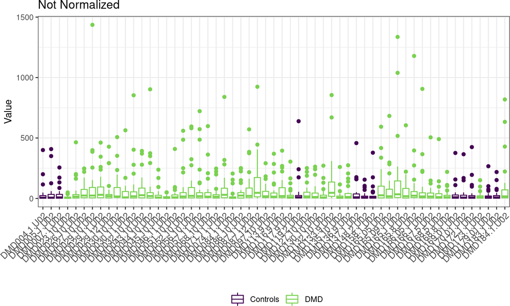

```r
a <- PomaBoxplots(none,
                  group = "samples",
                  jitter = FALSE) +
  ggplot2::ggtitle("Not Normalized")

b <- PomaBoxplots(auto_scaling,
                  group = "samples",
                  jitter = FALSE,
                  legend_position = "none") +
  ggplot2::ggtitle("Auto Scaling") +
  ggplot2::theme(axis.text.x = ggplot2::element_blank())

c <- PomaBoxplots(level_scaling,
                  group = "samples",
                  jitter = FALSE,
                  legend_position = "none") +
  ggplot2::ggtitle("Level Scaling") +
  ggplot2::theme(axis.text.x = ggplot2::element_blank())

d <- PomaBoxplots(log_scaling,
                  group = "samples",
                  jitter = FALSE,
                  legend_position = "none") +
  ggplot2::ggtitle("Log Scaling") +
  ggplot2::theme(axis.text.x = ggplot2::element_blank())

e <- PomaBoxplots(log_transformation,
                  group = "samples",
                  jitter = FALSE,
                  legend_position = "none") +
  ggplot2::ggtitle("Log Transformation") +
  ggplot2::theme(axis.text.x = ggplot2::element_blank())

f <- PomaBoxplots(vast_scaling,
                  group = "samples",
                  jitter = FALSE,
                  legend_position = "none") +
  ggplot2::ggtitle("Vast Scaling") +
  ggplot2::theme(axis.text.x = ggplot2::element_blank())

g <- PomaBoxplots(log_pareto,
                  group = "samples",
                  jitter = FALSE,
                  legend_position = "none") +
  ggplot2::ggtitle("Log Pareto") +
  ggplot2::theme(axis.text.x = ggplot2::element_blank())

a
```

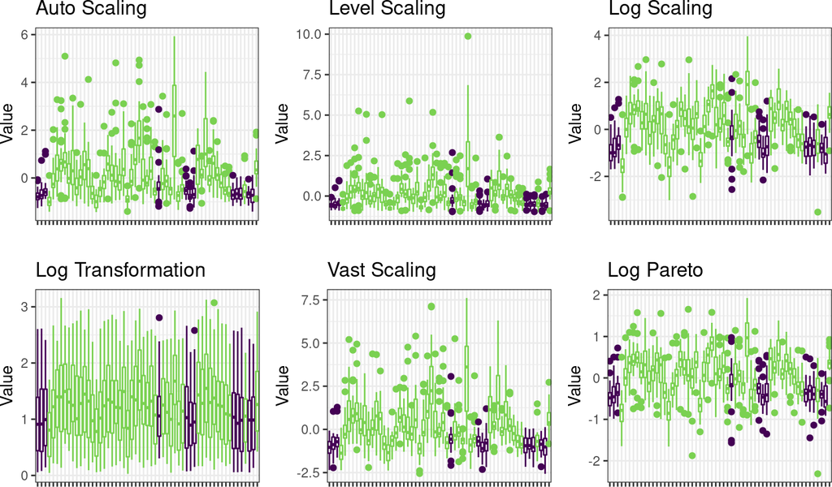

```r
(b + c + d) / (e + f + g)
```

## 4.3 Normalization effect on features

Here we can evaluate the different normalization effects on features.

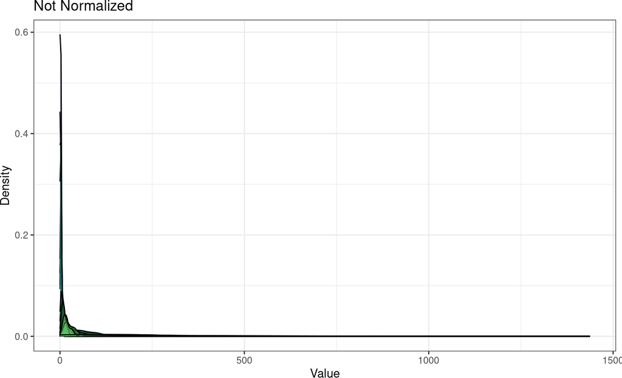

```r
h <- PomaDensity(none,
                 group = "features",
                 legend_position = "none") +
  ggplot2::ggtitle("Not Normalized")

i <- PomaDensity(auto_scaling,
                 group = "features",
                 legend_position = "none") +
  ggplot2::ggtitle("Auto Scaling") +
  ggplot2::theme(axis.title.x = ggplot2::element_blank(),
                 axis.title.y = ggplot2::element_blank())

j <- PomaDensity(level_scaling,
                 group = "features",
                 legend_position = "none") +
  ggplot2::ggtitle("Level Scaling") +
  ggplot2::theme(axis.title.x = ggplot2::element_blank(),
                 axis.title.y = ggplot2::element_blank())

k <- PomaDensity(log_scaling,
                 group = "features",
                 legend_position = "none") +
  ggplot2::ggtitle("Log Scaling") +
  ggplot2::theme(axis.title.x = ggplot2::element_blank(),
                 axis.title.y = ggplot2::element_blank())

l <- PomaDensity(log_transformation,
                 group = "features",
                 legend_position = "none") +
  ggplot2::ggtitle("Log Transformation") +
  ggplot2::theme(axis.title.x = ggplot2::element_blank(),
                 axis.title.y = ggplot2::element_blank())

m <- PomaDensity(vast_scaling,
                 group = "features",
                 legend_position = "none") +
  ggplot2::ggtitle("Vast Scaling") +
  ggplot2::theme(axis.title.x = ggplot2::element_blank(),
                 axis.title.y = ggplot2::element_blank())

n <- PomaDensity(log_pareto,
                 group = "features",
                 legend_position = "none") +
  ggplot2::ggtitle("Log Pareto") +
  ggplot2::theme(axis.title.x = ggplot2::element_blank(),
                 axis.title.y = ggplot2::element_blank())

h
```

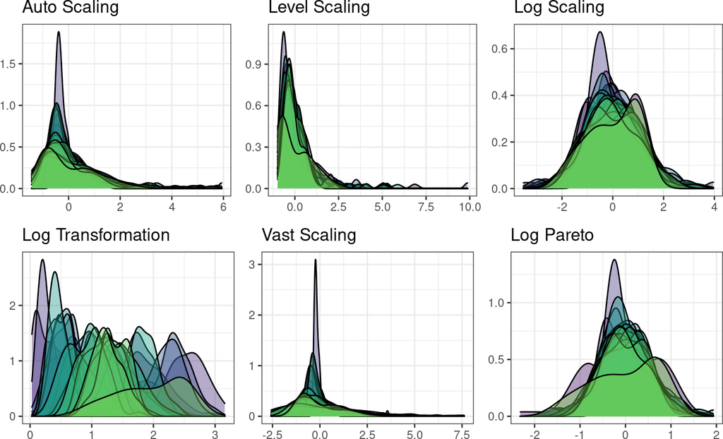

```r
(i + j + k) / (l + m + n)
```

# 5 Session Information

```r
sessionInfo()
> R version 4.2.1 (2022-06-23)
> Platform: x86_64-pc-linux-gnu (64-bit)
> Running under: Ubuntu 20.04.5 LTS
>
> Matrix products: default
> BLAS:   /home/biocbuild/bbs-3.16-bioc/R/lib/libRblas.so
> LAPACK: /home/biocbuild/bbs-3.16-bioc/R/lib/libRlapack.so
>
> locale:
>  [1] LC_CTYPE=en_US.UTF-8       LC_NUMERIC=C
>  [3] LC_TIME=en_GB              LC_COLLATE=C
>  [5] LC_MONETARY=en_US.UTF-8    LC_MESSAGES=en_US.UTF-8
>  [7] LC_PAPER=en_US.UTF-8       LC_NAME=C
>  [9] LC_ADDRESS=C               LC_TELEPHONE=C
> [11] LC_MEASUREMENT=en_US.UTF-8 LC_IDENTIFICATION=C
>
> attached base packages:
> [1] stats4    stats     graphics  grDevices utils     datasets  methods
> [8] base
>
> other attached packages:
>  [1] patchwork_1.1.2             SummarizedExperiment_1.28.0
>  [3] Biobase_2.58.0              GenomicRanges_1.50.0
>  [5] GenomeInfoDb_1.34.0         IRanges_2.32.0
>  [7] S4Vectors_0.36.0            BiocGenerics_0.44.0
>  [9] MatrixGenerics_1.10.0       matrixStats_0.62.0
> [11] plotly_4.10.0               ggraph_2.1.0
> [13] ggplot2_3.3.6               POMA_1.8.0
> [15] BiocStyle_2.26.0
>
> loaded via a namespace (and not attached):
>   [1] circlize_0.4.15        backports_1.4.1        plyr_1.8.7
>   [4] igraph_1.3.5           lazyeval_0.2.2         splines_4.2.1
>   [7] BiocParallel_1.32.0    listenv_0.8.0          digest_0.6.30
>  [10] foreach_1.5.2          htmltools_0.5.3        viridis_0.6.2
>  [13] magick_2.7.3           fansi_1.0.3            magrittr_2.0.3
>  [16] doParallel_1.0.17      cluster_2.1.4          limma_3.54.0
>  [19] ComplexHeatmap_2.14.0  recipes_1.0.2          globals_0.16.1
>  [22] graphlayouts_0.8.3     gower_1.0.0            rARPACK_0.11-0
>  [25] hardhat_1.2.0          colorspace_2.0-3       ggrepel_0.9.1
>  [28] xfun_0.34              dplyr_1.0.10           crayon_1.5.2
>  [31] RCurl_1.98-1.9         jsonlite_1.8.3         impute_1.72.0
>  [34] survival_3.4-0         iterators_1.0.14       glue_1.6.2
>  [37] polyclip_1.10-4        gtable_0.3.1           ipred_0.9-13
>  [40] zlibbioc_1.44.0        XVector_0.38.0         GetoptLong_1.0.5
>  [43] DelayedArray_0.24.0    future.apply_1.9.1     shape_1.4.6
>  [46] scales_1.2.1           DBI_1.1.3              Rcpp_1.0.9
>  [49] viridisLite_0.4.1      clue_0.3-62            proxy_0.4-27
>  [52] lava_1.7.0             prodlim_2019.11.13     glmnet_4.1-4
>  [55] htmlwidgets_1.5.4      httr_1.4.4             FNN_1.1.3.1
>  [58] RColorBrewer_1.1-3     ellipsis_0.3.2         pkgconfig_2.0.3
>  [61] farver_2.1.1           uwot_0.1.14            nnet_7.3-18
>  [64] sass_0.4.2             utf8_1.2.2             caret_6.0-93
>  [67] tidyselect_1.2.0       labeling_0.4.2         rlang_1.0.6
>  [70] reshape2_1.4.4         munsell_0.5.0          tools_4.2.1
>  [73] cachem_1.0.6           cli_3.4.1              dbscan_1.1-11
>  [76] generics_0.1.3         broom_1.0.1            evaluate_0.17
>  [79] stringr_1.4.1          fastmap_1.1.0          yaml_2.3.6
>  [82] ModelMetrics_1.2.2.2   knitr_1.40             tidygraph_1.2.2
>  [85] purrr_0.3.5            randomForest_4.7-1.1   glasso_1.11
>  [88] future_1.28.0          nlme_3.1-160           compiler_4.2.1
>  [91] png_0.1-7              e1071_1.7-12           tibble_3.1.8
>  [94] tweenr_2.0.2           bslib_0.4.0            stringi_1.7.8
>  [97] highr_0.9              RSpectra_0.16-1        lattice_0.20-45
> [100] Matrix_1.5-1           vegan_2.6-4            permute_0.9-7
> [103] vctrs_0.5.0            pillar_1.8.1           lifecycle_1.0.3
> [106] BiocManager_1.30.19    GlobalOptions_0.1.2    jquerylib_0.1.4
> [109] data.table_1.14.4      bitops_1.0-7           corpcor_1.6.10
> [112] R6_2.5.1               bookdown_0.29          gridExtra_2.3
> [115] parallelly_1.32.1      codetools_0.2-18       MASS_7.3-58.1
> [118] assertthat_0.2.1       rjson_0.2.21           withr_2.5.0
> [121] GenomeInfoDbData_1.2.9 mgcv_1.8-41            parallel_4.2.1
> [124] mixOmics_6.22.0        grid_4.2.1             rpart_4.1.19
> [127] timeDate_4021.106      tidyr_1.2.1            class_7.3-20
> [130] rmarkdown_2.17         Cairo_1.6-0            pROC_1.18.0
> [133] ggforce_0.4.1          lubridate_1.8.0        ellipse_0.4.3
```

# References

Berg, Robert A van den, Huub CJ Hoefsloot, Johan A Westerhuis, Age K Smilde, and Mariët J van der Werf. 2006. “Centering, Scaling, and Transformations: Improving the Biological Information Content of Metabolomics Data.” *BMC Genomics* 7 (1): 142.